# Species Summary Japanese Sardine

NPFC Japanese Sardine Small Working Group

2022-08-22

# Japanese sardine (*Sardinops melanostictus*)

**Common names:**

拟沙丁鱼, Ni Sha Ding Yu (China)

マイワシ, Maiwashi (Japan)

정어리, Jeong-eoli (Korea)

Дальневосточная сардина (Russia)

遠東擬沙丁魚, Yuan-Dong-Ni-Sha-Ding-Yu (Chinese Taipei)

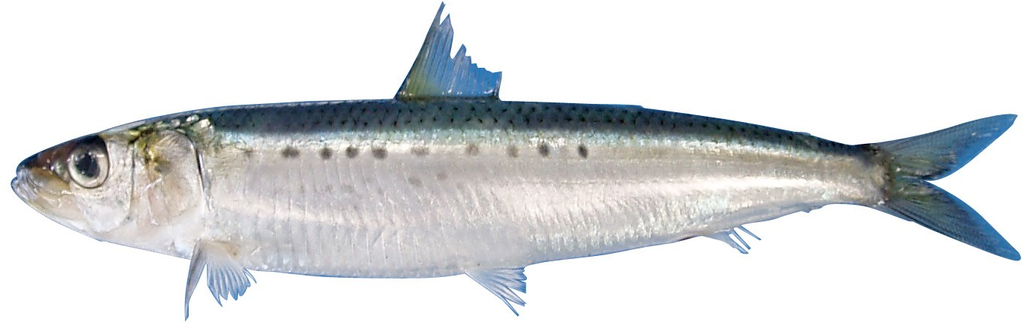

Figure 1. Japanese Sardine (*Sardinops melanostictus*).

## Management

### Active NPFC Management Measures

The following NPFC conservation and mangement measure (CMM) pertains to this species:

- CMM 2021-11 For Japanese Sardine, Neon Flying Squid and Japanese Flying Squid

Available from https://www.npfc.int/active-conservation-and-management-measures

### Management Summary

The current management measure for Japanese Sardine does not specify catch or effort limits. The CMM states that Members and Cooperating non-Contracting Parties currently harvesting Japanese Sardine should refrain from expansion of the number of fishing vessels authorized to fish Japanese Sardine in the Convention Area. New harvest capacity should also be avoided until as stock assessment has been completed.

A stock assessment for Japanese Sardine is conducted by Japan within their EEZ and used for management of the domestic fishery.

Table 1. Management Summary

| Convention or Management Principle | Status | Comment or Consideration |
| --- | --- | --- |
| Biological reference point(s) | Not accomplished | Not established |
| Stock status | Unknown | Status determination criteria not established |
| Catch limit | Intermediate | Recommended catch, effort limits |
| Harvest control rule | Not accomplished | Not established |
| Other | Intermediate | No expansion of fishing beyond established areas |

## Assessment

There is currently no stock assessment for Japanese Sardine conducted by NPFC for the Convention Area.

Japan conducts an assessment of the Japanese Sardine stock using VPA and a number of data sources described below (Hiroshi and Nishida 2005).

## Data

### Surveys

Japan conducts three surveys that estimate recruitment for a number of pelagic species, including Japanese Sardine (Table 2). The surveys target pre-recruits and juveniles to determine an index of recruitment. Japan also conducts a monthly egg and larval survey that is used to estimate spawning stock biomass. Surveys are conducted in spring (1995-2020), summer (2001-2020) and fall (2005-2020) at 30-80 stations per year. The survey protocol can be found at (Oozeki et al. 2007). Russia has conducted a summertime acoustic-trawl survey since 2010 that examines mid-water and upper epipelagic species including Japanese Sardine.

### Fishery

China, Japan and Russia catch Japanese sardine. China does not target the species, but it is captured as bycatch in other fisheries (e.g. chub mackerel). Catches are primarily by purse seine, with a smaller component of the catch taken by pelagic trawl. China’s catch of Japanese Sardine is taken exclusively from the Convention Area from April to December. China’s existing catch records are from 2016 to 2020 and show increasing catches during that time period as the stock may have been increasing. The historical catches (prior to 2016) are unknown, thought to be low and likely need to be confirmed.

Japan’s fishery for Japanese Sardine occurs inside their EEZ and is mostly conducted by large purse seine vessels (>90% of the catch). Additional components of the fishery include set nets, dip nets and other gears. The fishery experienced very high catches in the 1980’s and early 1990’s, a decline to very low catches from 1995 to ~2010 and has been recovering since then. The fishery is conducted year round, but mainly during the summer season.

The Russian fishery occurs inside their EEZ and is prosecuted primarily by pelagic trawling (>90% of the catch), with a smaller component of the catch coming from purse seines. The success of Russian fishery depends on the migration patterns and overall abundance of Japanese Sardine, as the sardine move into Russian waters when their abundance is high. For this reason, there was no catch from 1994-2011 when the stock abundance was low, but in recent years (since 2016) as the stock has recovered and water temperatures have been warm there have been increasing catches in Russia. The Russian fishery occurs primarily from June to November.

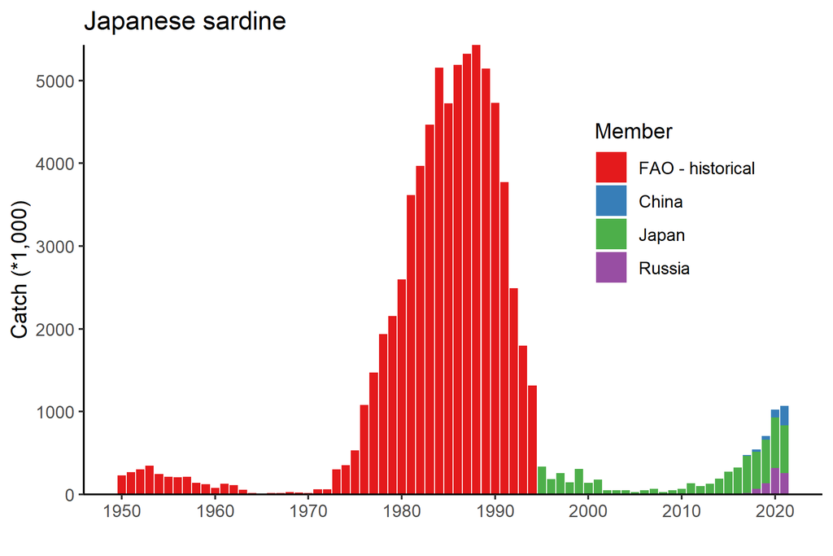

Figure 2. Historical catch of Japanese Sardine.

Other NPFC Members (Canada, Korea, Chinese Taipei, USA and Vanuatu) do not target Japanese Sardine. Chinese Taipei has some historical records of Japanese Sardine bycatch in the Pacific Saury fishery (~100 mt) and Korea has a small amount of historical bycatch data from the bottom trawl fishery. Vanuatu, USA and Canada have no record of Japanese Sardine catches.

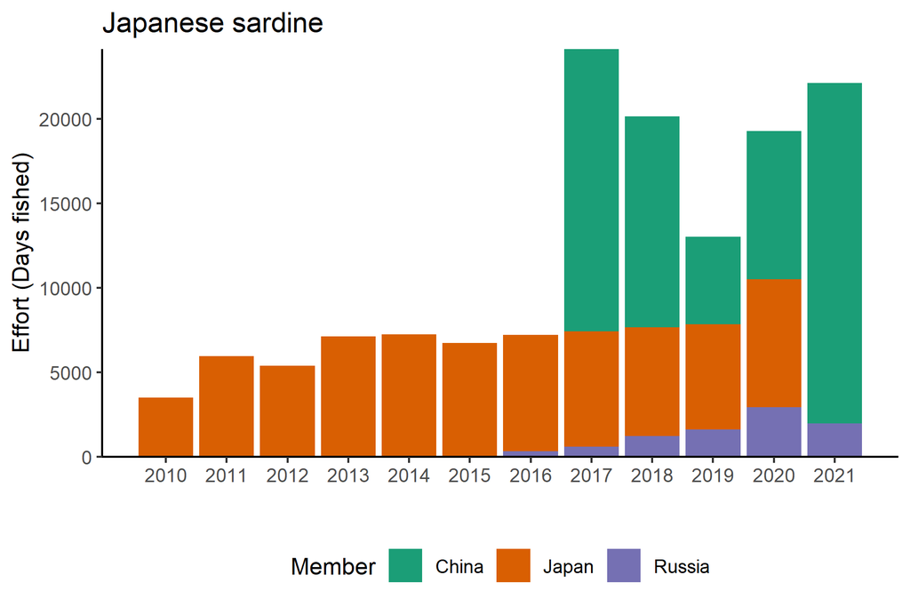

Figure 3. Historical fishing effort for Japanese Sardine.

### Biological collections

China collected biological data from fishery catches of Japanese Sardine in 2020. These collections included length data as well as maturity and age structures.

Russia collects length and weight data, age structures (scales) and maturity data from both commercial catches and surveys.

Japan also collects length, weight, maturity and age data from the survey and fishery to support their stock assessment.

Table 2. Data availability from Members regarding Japanese Sardine

| Data | Source | Years | Comment |
| --- | --- | --- | --- |
| Catch | China | 2016-present | Catches from convention area |
|  | Japan | 1995-present | Historical catch data from 1968 available, catches in national waters |
|  | Korea |  | Minor bycatch in bottom trawl fishery |
|  | Russia | 2016-present | Catches primarily in national waters, not convention area |
|  | Chinese Taipei |  | Minor bycatch in Pacific saury fishery |
| CPUE |  |  | not developed |
| Survey | Japan |  | Pre-recruit survey |
|  | Japan |  | Juvenile survey |
|  | Japan |  | Monthly egg and larval survey |
|  | Russia | 2010-present | Acoustic-trawl survey |
| Age data | China | 2020 | Commercial catch |
|  | Japan |  | Commercial and survey catches |
|  | Russia |  | Commercial and survey catches |
| Length data | China | 2020 | Commercial catch |
|  | Japan |  | Commercial and survey catches |
|  | Russia |  | Commercial and survey catches |
| Maturity/fecundity | China | 2020 | Commercial catch |
|  | Japan |  | Commercial and survey catches |
|  | Russia |  | Commercial and survey catches |

## Special Comments

None

## Biological Information

### Distribution

Japanese sardine (*Sardinops melanostichtus*; Figure 1) are a pelagic species that occurs in large migratory schools in the coastal waters of China, Chinese Taipei, Japan, Korea and Russia (Figure 4, (Kaschner et al. 2019)). They generally migrate from the south to the north during summer, returning to inshore areas in the south to spawn in the winter. Japanese sardine feed mainly on zooplankton and phytoplankton.

### Life history

Japanese sardine are short-lived and fast growing, maturing early at 2-years old. Their maximum length is ~24 cm and their maximum reported age is 25 years (Whitehead 1985). Their growth rates and spawning patterns are highly influenced by the environment (Niino et al. 2021)

Taxonomically, the Japanese sardine are closely related to other species around the globe including Sardinops from southern Africa, Australia, South America and California.

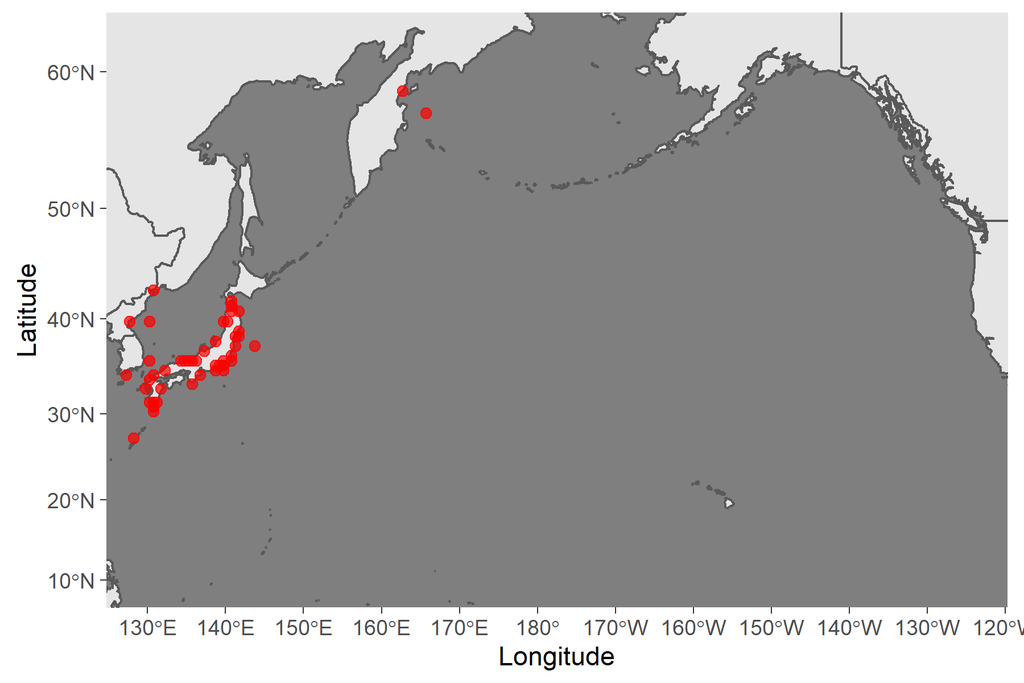

Figure 4. Map of distribution of Sardine species in the North Pacific.

## Appendix: Sardine and the environment

| Reference | Year.published | Report.type | Country.of.study | Ocean | Region.studied | Focus.species.Common.Name | Life.stage.studied..Adult..Juvenile..Larval..Egg. | Life.History.Parameter.examined | Environmental.variables.examined | Effect.of.environment | Study.method..correlation..time.series.analysis..multivariate.analysis..etc.. | Comment |
| --- | --- | --- | --- | --- | --- | --- | --- | --- | --- | --- | --- | --- |
| Kodama, T, Wagawa T, Ohshimo S, Morimoto H, Iguchi N, Fukudome KI, Goto T, Takahashi T, Yasuda T. 2018. Improvement in Recruitment of Japanese Sardine with Delays of the Spring Phytoplankton Bloom in … | 2018 | journal paper | Japan | Pacific | Sea of Japan | Japanese sardine | Larvae | Recruitment | Sea surface chlorophyl a | delay in start and end dates of spring bloom were positively correlated with recruitment | Correlation, empirical orthoganal function | NA |
| Yasuda, Tohya, Satoshi Kitajima, Akira Hayashi, Motomitsu Takahashi, and Masa aki Fukuwaka. 2021. “Cold Offshore Area Provides a Favorable Feeding Ground with Lipid-Rich Foods for Juvenile Japanese Sa… | 2021 | journal paper | Japan | Pacific | Sea of Japan | Japanese sardine | juvenile | Body condition | Prey species and temperature | higher condition in offshore distributed fish due to lower temperature and higher lipid content prey | correlation | NA |
| Nishikawa, Haruka. 2019. “Relationship between Recruitment of Japanese Sardine (Sardinops Melanostictus) and Environment of Larval Habitat in the Low-Stock Period (1995–2010).” Fisheries Oceanography … | 2019 | journal paper | Japan | Pacific | Kuoshio current | Japanese sardine | Larvae | Recruitment | water temperature and larval drift | warmer temperature related to lower recruitment | correlation | NA |
| Niino, Yohei, Sho Furuichi, Yasuhiro Kamimura, and Ryuji Yukami. 2021. “Spatiotemporal Spawning Patterns and Early Growth of Japanese Sardine in the Western North Pacific during the Recent Stock Incre… | 2021 | journal paper | Japan | Pacific | Kuoshio current | Japanese sardine | Larvae | growth | spawning distribution and timing (temperature) | early spawning in eastern area contributed to higher recruitment during time of increasing sardine biomass | correlation | NA |
| Muko, Soyoka, Seiji Ohshimo, Hiroyuki Kurota, Tohya Yasuda, and Masa Aki Fukuwaka. 2018. “Long-Term Change in the Distribution of Japanese Sardine in the Sea of Japan during Population Fluctuations.” … | 2018 | journal paper | Japan | Pacific | Sea of Japan | Japanese sardine | Adult | Distribution (SDM) | sea surface temperature | dome shaped relationship between sea surface temperature and the probability of presence, with peak between 10-20 C | generalized additive models | NA |
| Sogawa, Sayaka, Kiyotaka Hidaka, Yasuhiro Kamimura, Masanori Takahashi, Hiroaki Saito, Yuji Okazaki, Yugo Shimizu, and Takashi Setou. 2019. “Environmental Characteristics of Spawning and Nursery Groun… | 2019 | journal paper | Japan | Pacific | Kuoshio current | Japanese sardine | Egg | Distribution | water temperature, larval drift, zooplankton | little variability in environment where eggs were found, copepod community structure was important | correlation | NA |
| Kuroda, Hiroshi, Toshihiko Saito, Toshiki Kaga, Akinori Takasuka, Yasuhiro Kamimura, Sho Furuichi, and Takuya Nakanowatari. 2020. “Unconventional Sea Surface Temperature Regime Around Japan in the 200… | 2020 | journal paper | Japan | Pacific | Pacific | Japanese sardine | Adult | Recruitment | PDO, SST | spawning was earlier during SST increases | correlation | NA |
| Ma, Shuyang, Yongjun Tian, Caihong Fu, Haiqing Yu, Jianchao Li, Yang Liu, Jiahua Cheng, Rong Wan, and Yoshiro Watanabe. 2021. “Climate-Induced Nonlinearity in Pelagic Communities and Non-Stationary Re… | 2020 | journal paper | China | Pacific | Kuoshio current | Japanese sardine | Adult | Abundance/Catch | Basin scale climate (ALPI, SST, Current patterns) | Climate variability introduced nonlinearity and nonstationarity to pelagic fish | time series analyses | NA |
| Kurota, Hiroyuki, Cody S. Szuwalski, and Momoko Ichinokawa. 2020. “Drivers of Recruitment Dynamics in Japanese Major Fisheries Resources: Effects of Environmental Conditions and Spawner Abundance.” Fi… | 2020 | journal paper | Japan | Pacific | Pacific | Japanese sardine | Adult | Recruitment | "Environment" other than SSB | Regime shifts were detected in pelagic species | time series analyses, change point analysis | NA |
| Furuichi, Sho, Tohya Yasuda, Hiroyuki Kurota, Mari Yoda, Kei Suzuki, Motomitsu Takahashi, and Masa Aki Fukuwaka. 2020. “Disentangling the Effects of Climate and Density-Dependent Factors on Spatiotemp… | 2020 | journal paper | Japan | Pacific | Sea of Japan | Japanese sardine | Egg | Abundance and distribution | SST | Cold water led to decreased egg abundance over larger area, warm temperatures led to earlier spawning | correlation | NA |
| Okazaki, Yuji, Kazuaki Tadokoro, Hiroshi Kubota, Yasuhiro Kamimura, and Kiyotaka Hidaka. 2019. “Dietary Overlap and Optimal Prey Environments of Larval and Juvenile Sardine and Anchovy in the Mixed Wa… | 2019 | journal paper | Japan | Pacific | Kuoshio current | NA | larvae and juvenile | prey habits | SST | Temperature influences abundance of prey with effect on recruitment | correlation | NA |

Hiroshi, and Nishida. 2005. “Stock Assessment and ABC Calculation for Japanese Sardine (Sardinops Melanostictus) in the Northwestern Pacific Under Japanese TAC System.” In.

Karthik Ram, Carl Boettiger, and Andrew Dyck. 2013. “Rfisheries: R Interface for Fisheries Data. R Package Version 0.1.” 2013. http://CRAN.R-project.org/package=rfisheries.

Kaschner, K., Kesner-Reyes K., Garilao C., Segschneider J., J. Rius-Barile, Rees T., and R. Froese. 2019. “AquaMaps: Predicted Range Maps for Aquatic Species. Data Retrieved from Https://Www.aquamaps.org.”

Niino, Yohei, Sho Furuichi, Yasuhiro Kamimura, and Ryuji Yukami. 2021. “Spatiotemporal spawning patterns and early growth of Japanese sardine in the western North Pacific during the recent stock increase.” *Fisheries Oceanography*, no. April: 1–10. https://doi.org/10.1111/fog.12542.

Oozeki, Yoshioki, Akinori Takasuka, Hiroshi Kubota, and Manuel Barange. 2007. “Characterizing Spawning Habitats of Japanese Sardine (Sardinops Melanostictus), Japanese Anchovy (Engraulis Japonicus), and Pacific Round Herring (Etrumeus Teres) in the Northwestern Pacific.” *CalCOFI Rep.* 48 (December).

Whitehead, Peter J. P. 1985. “FAO Species Catalogue. Vol. 7. Clupeoid Fishes of the World (Suborder Clupeoidei). An Annotated and Illustrated Catalogue of the Herrings, Sardines, Pilchards, Sprats, Shads, Anchovies and Wolf-Herrings.” *FAO Fish. Synop.* 125(7/1): 1–303.